# Data Mining: Crafting Video Games through Time

Author

Mia Keene, Camilo Humphrey, Kara Rippe, and Zoë White

## Overview

As a cross disciplinary team, we felt something widespread would cater to all our fields. Video games are something anyone can play, and with this data, it is all self-documented from the game collection site, Backloggd. This allows us to see what players value enough to record.

We thought there would be interesting fluctuations over time to explore in the data as well as our interest in the field. Video games are a great way to see how media has changed through time and what elements, such as genres, narratives, and mechanics, have remained relevant across forty years.

One challenge is that this data is taken from a site launched in 2019, meaning some data for older games may be scarce if people didn’t feel the need to document their playthrough (e.g. someone who played pac-man in 1985 might not go on a collection site to make record of that). This data is still valuable to see trends, and again what is valued, as the gaming industry is massive and often more lucrative than both music and film mediums.

## Wrangling

We initially pulled this dataset from Kaggle.com since it looked very interesting but relatively easy to work with. Since there were less than 5 missing values on the entire 1,512 x 14 sheet, we did not manipulate the data prior to downloading it. Below are the packages we downloaded collectively to create our visualizations and tables followed by the tibble of the raw dataset.

```r
library(tidyverse)
library(gt)
library(lubridate)
library(patchwork)
library(stringr)
library(dplyr)
library(scales)
```

```r
# import raw data file
games <- read_csv("games.csv")
games
```

```
# A tibble: 1,512 × 14
    ...1 Title    `Release Date` Team  Rating `Times Listed` `Number of Reviews`
   <dbl> <chr>    <chr>          <chr>  <dbl> <chr>          <chr>
 1     0 Elden R… Feb 25, 2022   ['Ba…    4.5 3.9K           3.9K
 2     1 Hades    Dec 10, 2019   ['Su…    4.3 2.9K           2.9K
 3     2 The Leg… Mar 03, 2017   ['Ni…    4.4 4.3K           4.3K
 4     3 Underta… Sep 15, 2015   ['to…    4.2 3.5K           3.5K
 5     4 Hollow … Feb 24, 2017   ['Te…    4.4 3K             3K
 6     5 Minecra… Nov 18, 2011   ['Mo…    4.3 2.3K           2.3K
 7     6 Omori    Dec 25, 2020   ['OM…    4.2 1.6K           1.6K
 8     7 Metroid… Oct 07, 2021   ['Ni…    4.3 2.1K           2.1K
 9     8 Among Us Jun 15, 2018   ['In…    3   867            867
10     9 NieR: A… Feb 23, 2017   ['Pl…    4.3 2.9K           2.9K
# ℹ 1,502 more rows
# ℹ 7 more variables: Genres <chr>, Summary <chr>, Reviews <chr>, Plays <chr>,
#   Playing <chr>, Backlogs <chr>, Wishlist <chr>
```

Each coder wrangled the data individually to achieve their desired outcome:

- Camilo redefined the values in the `Number of Reviews` and `Ratings` columns as numerals and created a new column labeled `Genre Primary` to capture the first genre listed for every game.

```r
#-------------------------------
# 1. Clean numeric variables
#-------------------------------
games_clean <- games_clean |>
  mutate(
    number_of_reviews = as.numeric(`Number of Reviews`),
    rating = as.numeric(Rating)
  )

#-------------------------------
# 2. Create a primary genre (first listed)
#-------------------------------
games_clean <- games_clean |>
  mutate(GenrePrimary = str_extract(Genres, "^[^;]+"))
```

- Kara parsed the dates so that they could be appropriately standardized and marked unreleased titles as ‘NA’.

```r
# parsing dates
games_parsed <-
  games |>
mutate(
  release_date = mdy(`Release Date`),
  year = year(release_date)
)
```

- Zoë dropped NA/missing values, redefined the `Rating` column as numeric, arranged them in descending order, isolated the top 20, and removed all unnecessary characters in the `Genre` column.

```r
video_games <- read_csv("games.csv",
                          na = c("", "NA", "null", " ", "[]")) %>%
  mutate(rating = as.numeric(Rating)) %>%
  distinct(Title, .keep_all = TRUE) %>%
  arrange(desc(rating)) %>%
  slice_head(n = 20) %>%
  mutate(Genres = str_remove_all(Genres, "[\\[\\]']")) %>%
  select(Title, Genres, rating, Wishlist)
```

- Mia dropped ‘NA’ values in the `Ratings` column, removed special characters in the `Teams` column cells, and lengthened the dataset so that each development team would have their own row rather than being included in lists.

```r
# clean data by separating out Team vectors
games_clean <-
  games |>
  drop_na(Rating) |>
  select(Rating, Team) |>
  mutate(
    Team = str_remove_all(Team, "[\\[|\\]|']")
  ) |>
  separate_longer_delim(
    cols = Team,
    delim = ", "
  )
```

### Variables

**Title:** The published title of the game.

**Release Date:** When the game was released to the public for play.

**Team:** The moniker used by the creators/developers of the game.

**Rating:** The average rating on a scale of 0-5 given to the game by the users of the website Backloggd.

**Times Listed:** The count of individual users who reported playing the game on the website Backloggd.

**Number of Reviews:** The count of individual users who left a review of the game on the website Backloggd.

**Genres:** The categorical type(s) that the game is classified under.

## Visualizations

### Figure 1

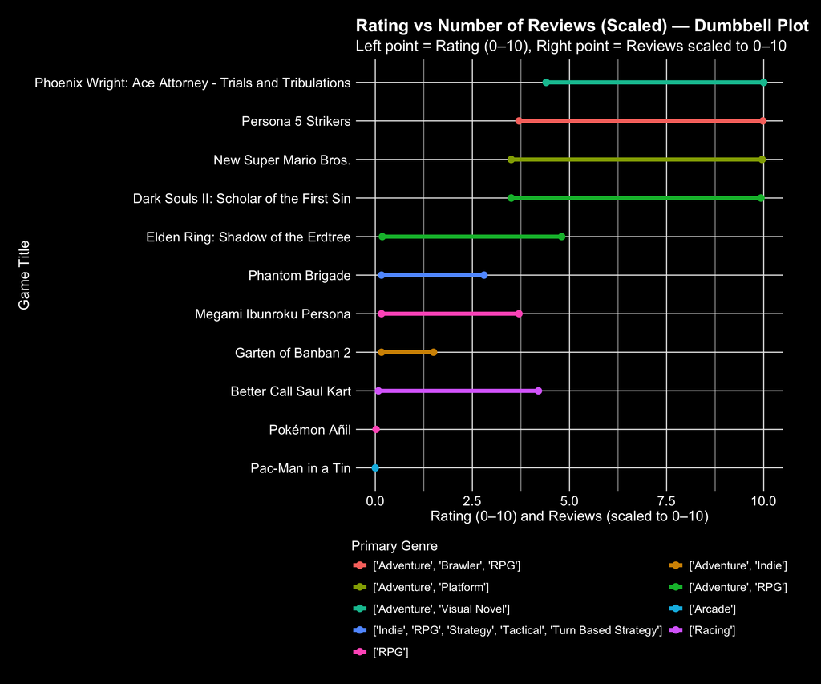

```r
games_clean <- read_csv("games.csv")

#-------------------------------
# 1. Clean numeric variables
#-------------------------------
games_clean <- games_clean |>
  mutate(
    number_of_reviews = as.numeric(`Number of Reviews`),
    rating = as.numeric(Rating)
  )

#-------------------------------
# 2. Create a primary genre (first listed)
#-------------------------------
games_clean <- games_clean |>
  mutate(GenrePrimary = str_extract(Genres, "^[^;]+"))

#-------------------------------
# 3. Select Top 7 + Bottom 7 games
#-------------------------------
top7 <- games_clean |> slice_max(number_of_reviews, n = 7)
bot7 <- games_clean |> slice_min(number_of_reviews, n = 7)

selected <- bind_rows(top7, bot7)

#-------------------------------
# 4. Scale reviews to match rating scale (0–10)
#-------------------------------
selected <- selected |>
  mutate(
    reviews_scaled = rescale(number_of_reviews, to = c(0, 10))
  )

#-------------------------------
# 5. Dumbbell Plot
#-------------------------------
ggplot(selected, aes(y = reorder(Title, number_of_reviews))) +
  geom_segment(
    aes(
      x = rating,
      xend = reviews_scaled,
      yend = reorder(Title, number_of_reviews),
      color = GenrePrimary
    ),
    linewidth = 2
  ) +
  geom_point(aes(x = rating, color = GenrePrimary), size = 3) +
  geom_point(aes(x = reviews_scaled, color = GenrePrimary), size = 3) +
  labs(
    title = "Rating vs Number of Reviews (Scaled) — Dumbbell Plot",
    subtitle = "Left point = Rating (0–10), Right point = Reviews scaled to 0–10",
    x = "Rating (0–10) and Reviews (scaled to 0–10)",
    y = "Game Title",
    color = "Primary Genre"
  ) +
   scale_color_discrete(name = "Primary Genre") +
  guides(color=guide_legend(nrow=5, byrow=TRUE)) +
 theme_minimal() +
  theme(
    plot.background  = element_rect(fill = "black", color = "black"),
    panel.background = element_rect(fill = "black", color = "black"),
    axis.text        = element_text(color = "white", size = 14),
    axis.title       = element_text(color = "white", size = 15),
    plot.title       = element_text(face = "bold", color = "white", size = 18),
    plot.subtitle    = element_text(color = "white", size = 16),
    legend.position  = "bottom",
    legend.text      = element_text(color = "white", size = 12),
    legend.title     = element_text(color = "white", size = 14),
    legend.title.position = "top",
    plot.margin      = margin(t = 20, r = 40, b = 20, l = 20)
  )
```

### Figure 2

These plots show the increase in logged game production and total play count across forty years. It compares video games users have documented on the site to total documented plays across time. Dates were parsed so that they could be appropriately standardized, and unreleased titles were marked as ‘NA’. Game count shows a steady increase, while total play count is more staggered through time. However, there is a major increase in both graphs after 2020, likely linked to the COVID-19 pandemic. This equates to more time for people to play games and log those playthroughs, as well as increased game production in the following years. However, global game releases in after 2020 had a noteable increase, according to Steam metrics. Earlier years have little to show, so it must be emphasized that these line graphs display what games were valued enough to be documented.

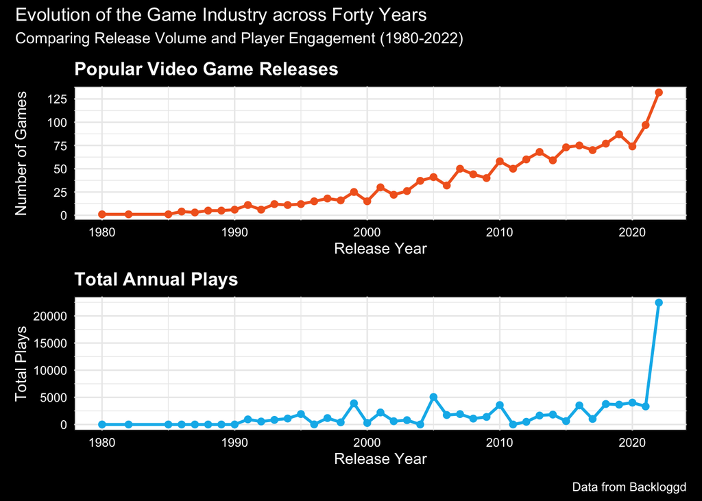

```r
# parsing dates
games_parsed <-
  games |>
mutate(
  release_date = mdy(`Release Date`),
  year = year(release_date)
)

# filtering NA, and obtaining count of years before 2022
release_year <-
  games_parsed |>
  filter(!is.na(year)) |>
  count(year) |>
  filter(year <= 2022)

# count of games over time
game_count <-
  ggplot(
  release_year,
       aes(
         x = year,
         y = n
       )
    ) +
  geom_line(color = "#F26522", size = 1) +
  geom_point(color = "#F26522", size = 2) +
  scale_y_continuous(breaks = seq(0, 125, by = 25)) +
    labs(
      title = "Popular Video Game Releases",
      y = "Number of Games",
      x = "Release Year"
    ) +
  theme_minimal() +
  theme(
  plot.title = element_text(face = "bold", color = "white"),
  text = element_text(color = "white"),
  axis.text = element_text(color = "white"),
  plot.background = element_rect(fill = "black", color = "black"),
  panel.background = element_rect(fill = "white"))

# filtering years
# standardizing total
total_plays_data <-
  games_parsed |>
  filter(!is.na(year) & year <= 2022) |>
  group_by(year) |>
  summarize(
    total_annual_plays = sum(as.numeric(Plays), na.rm = TRUE)
  )

# total plays plot
total_plays <-
  total_plays_data |>
ggplot(
  aes(
    x = year,
    y = total_annual_plays
  )
) +
  geom_line(
    color = "#00B7EB", size = 1) +
  geom_point(color = "#00B7EB", size = 2) +
  labs(
    title = "Total Annual Plays",
    x = "Release Year",
    y = "Total Plays"
  ) +
  theme_minimal() + theme(
  plot.title = element_text(face = "bold", color = "white"),
  text = element_text(color = "white"),
  axis.text = element_text(color = "white"),
  plot.background = element_rect(fill = "black", color = "black"),
  panel.background = element_rect(fill = "white"))

compared_plots <-
  game_count /  total_plays
compared_plots +
  plot_annotation(
    title = "Evolution of the Game Industry across Forty Years",
    subtitle = "Comparing Release Volume and Player Engagement (1980-2022)",
    caption = "Data from Backloggd") &
  theme(
    plot.background = element_rect(fill = "black", color = "black"),
    text = element_text(color = "white")
  )
```

## Tables

### Table 1

This table displays the top 20-rated video games by title, genre(s), user rating, and wishlist count. Duplicate titles were filtered out to accurately capture the spread, with most games falling within a 4.6 rating, while the number one game fell at 4.8. User rating and wishlist count can provide valuable insight into what players value in a game.

```r
video_games <- read_csv("games.csv",
                          na = c("", "NA", "null", " ", "[]")) %>%
  mutate(rating = as.numeric(Rating)) %>%
  distinct(Title, .keep_all = TRUE) %>%
  arrange(desc(rating)) %>%
  slice_head(n = 20) %>%
  mutate(Genres = str_remove_all(Genres, "[\\[\\]']")) %>%
  select(Title, Genres, rating, Wishlist)

top_20_table <- video_games %>%
  gt() %>%
  tab_header(
    title = md("**Elite Tier: Top 20 Unique Video Games**"),
    subtitle = "The highest-rated unique titles, excluding duplicate entries"
  ) %>%
  cols_label(
    Title = "Game Title",
    Genres = "Genre(s)",
    rating = "User Rating",
    Wishlist = "Wishlist Count"
  ) %>%
  fmt_number(
    columns = rating,
    decimals = 1
  ) %>%
  tab_options(
    table.width = px(700),
    column_labels.background.color = "#f8f9fa",
    column_labels.font.weight = "bold"
  ) %>%
  sub_missing(
    columns = everything(),
    missing_text = "N/A"
  ) %>%
  tab_source_note(
    source_note = "Source: Video_Games - games.csv"
  ) %>%
  tab_options(
    table.background.color = "black",
    column_labels.background.color = "black",
    table.font.color = "white"
  )

top_20_table
```

**Elite Tier: Top 20 Unique Video Games**

The highest-rated unique titles, excluding duplicate entries

| Game Title | Genre(s) | User Rating | Wishlist Count |
| --- | --- | --- | --- |
| Elden Ring: Shadow of the Erdtree | Adventure, RPG | 4.8 | 146 |
| Disco Elysium: The Final Cut | Adventure, Indie, RPG | 4.6 | 2.7K |
| Outer Wilds | Adventure, Indie, Puzzle, Simulator | 4.6 | 3.1K |
| Disco Elysium | Adventure, RPG, Turn Based Strategy | 4.6 | 1.9K |
| Umineko: When They Cry Chiru | Adventure, Visual Novel | 4.6 | 493 |
| Bloodborne: The Old Hunters | Adventure, RPG | 4.6 | 616 |
| Hitman World of Assassination | Adventure, Shooter, Tactical | 4.6 | 54 |
| Final Fantasy XIV: Endwalker | Adventure, RPG | 4.6 | 391 |
| Metal Gear Solid 3: Subsistence | Adventure, Shooter, Tactical | 4.6 | 639 |
| Final Fantasy XIV: Shadowbringers | RPG | 4.6 | 267 |
| The Great Ace Attorney 2: Resolve | Adventure, Point-and-Click, Puzzle, Visual Novel | 4.6 | 468 |
| Sekiro: Shadows Die Twice - GOTY Edition | Adventure, Brawler, RPG | 4.6 | 373 |
| Half-Life: Alyx | Adventure, Puzzle, Shooter | 4.6 | 1.4K |
| Dwarf Fortress | Indie, RPG, Simulator, Strategy | 4.6 | 195 |
| Metal Gear Solid 3: Snake Eater HD Edition | Adventure, Shooter | 4.6 | 244 |
| Tokyo Necro | Adventure, Visual Novel | 4.6 | 69 |
| Bloodborne: Game of the Year Edition | RPG | 4.6 | 255 |
| Elden Ring | Adventure, RPG | 4.5 | 4.8K |
| Bloodborne | Adventure, RPG | 4.5 | 3.3K |
| Silent Hill 2 | Adventure, Puzzle | 4.5 | 2.1K |

Source: Video_Games - games.csv

### Table 2

This table shows the average user ratings earned by development teams as well as how many games each team made. It highlights the top 10 and bottom 10 ratings and also includes all developers who made 30 or more games for the sake of comparison. It is notable that all but 2 teams in the highest and lowest rated categories have made only 1-2 games each. In contrast, the teams that have made over 30 games each have an average rating in the mid-high range, between 3.40 and 4.15 out of 5 possible points. This table includes details about 35 developers out of 661 in the full dataset.

```r
# clean data by separating out Team vectors
games_clean <-
  games |>
  drop_na(Rating) |>
  select(Rating, Team) |>
  mutate(
    Team = str_remove_all(Team, "[\\[|\\]|']")
  ) |>
  separate_longer_delim(
    cols = Team,
    delim = ", "
  )

# calculate average ratings and games made by developer
team_ratings <-
  games_clean |>
  summarize(
    .by = Team,
    avg_rating = round(mean(Rating, na.rm = TRUE), 2),
    n_games = n()
  )

# identify top 10, bottom 10, and biggest developers
top10_ratings <-
  team_ratings |>
  arrange(desc(avg_rating)) |>
  slice_head(n = 10)

bottom10_ratings <-
  team_ratings |>
  arrange(desc(avg_rating)) |>
  slice_tail(n = 10)

most_games <-
  team_ratings |>
  filter(n_games >= 30) |>
  arrange(desc(avg_rating))

# combine
combined_ratings <-
  bind_rows(top10_ratings, most_games, bottom10_ratings)

# create table
ratings_table <-
  combined_ratings |>
  gt(
    rowname_col = "Team"
  ) |>
  tab_stubhead(
    label = "Development Team"
  ) |>
  tab_header(
    title = md("**Average Game Ratings by Developer**"),
    subtitle = "Top 10 and Bottom 10 Scores and Biggest Developers"
  ) |>
  cols_label(
    avg_rating = "Average Rating",
    n_games = "Games Made"
  ) |>
  tab_style(
    style = cell_fill(color = "green"),
    locations = cells_body(rows = 1:10)
  ) |>
  tab_style(
    style = cell_fill(color = "firebrick1"),
    locations = cells_body(rows = 26:35)
  ) |>
  tab_style(
    style = cell_fill(color = "blue"),
    locations = cells_body(rows = 11:25)
  ) |>
  tab_options(
    table.background.color = "black",
    column_labels.background.color = "black",
    table.font.color = "white"
  )

ratings_table
```

**Average Game Ratings by Developer**

Top 10 and Bottom 10 Scores and Biggest Developers

| Development Team | Average Rating | Games Made |
| --- | --- | --- |
| ZA/UM | 4.60 | 6 |
| Inlusio Interactive | 4.60 | 1 |
| Bay 12 Games | 4.60 | 1 |
| Kitfox Games | 4.60 | 1 |
| Konami Digital Entertainment | 4.60 | 1 |
| Mobius Digital | 4.57 | 4 |
| Tour De Pizza | 4.50 | 1 |
| EA | 4.50 | 2 |
| CD Projekt | 4.50 | 2 |
| Aniplex | 4.50 | 1 |
| FromSoftware | 4.15 | 30 |
| Sony Interactive Entertainment | 4.01 | 43 |
| Atlus | 3.92 | 36 |
| Konami | 3.88 | 39 |
| Nintendo EAD | 3.88 | 37 |
| Square Enix | 3.84 | 77 |
| Nintendo | 3.80 | 244 |
| Sony Computer Entertainment | 3.80 | 44 |
| Capcom | 3.77 | 89 |
| Bandai Namco Entertainment | 3.75 | 42 |
| Bethesda Softworks | 3.68 | 32 |
| Electronic Arts | 3.63 | 58 |
| Activision | 3.54 | 37 |
| Sega | 3.51 | 63 |
| Ubisoft Entertainment | 3.40 | 32 |
| Matheus Valadares | 2.20 | 2 |
| Lowtech Studios | 2.20 | 1 |
| Steve Howse | 2.20 | 1 |
| GOA Games Services Ltd. | 2.10 | 2 |
| Iggymob | 2.10 | 1 |
| Red Entertainment | 2.10 | 1 |
| Double Helix Games | 2.10 | 1 |
| Parsec Productions | 2.00 | 1 |
| Euphoric Brothers | 1.35 | 2 |
| Titus Software | 0.70 | 1 |

## Conclusions

**Interesting fact:** There is a difference between popularity and quality of video games, with widely rated games sometimes having more average scores than those with fewer ratings.